# Pertemuan 1 Pemulusan

## SES

### Eksplorasi

Eksplorasi dilakukan dengan membuat plot data deret waktu untuk keseluruhan data, data latih, dan data uji.

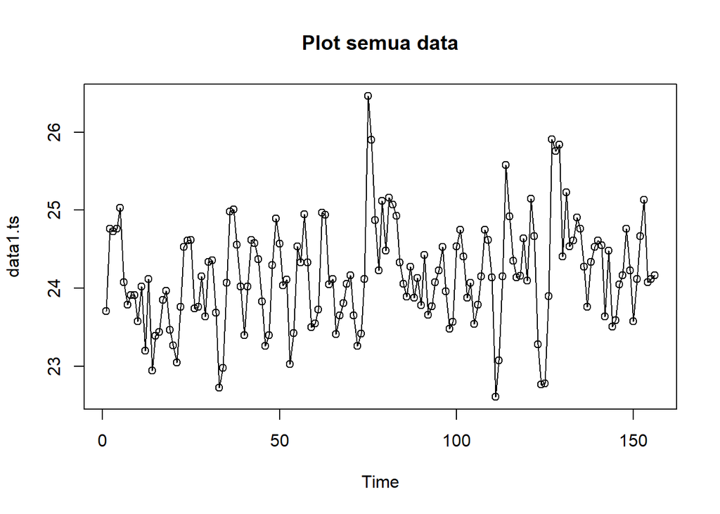

```r
#eksplorasi data
plot(data1.ts, col="black",main="Plot semua data")
points(data1.ts)
```

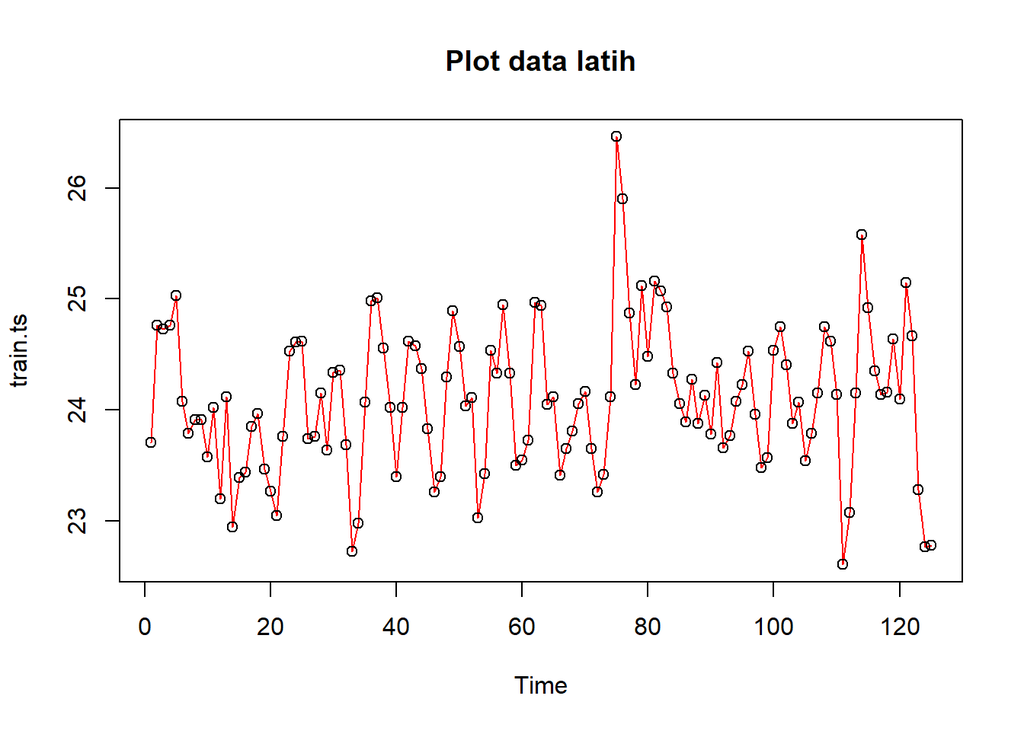

```r
plot(train.ts, col="red",main="Plot data latih")
points(train.ts)
```

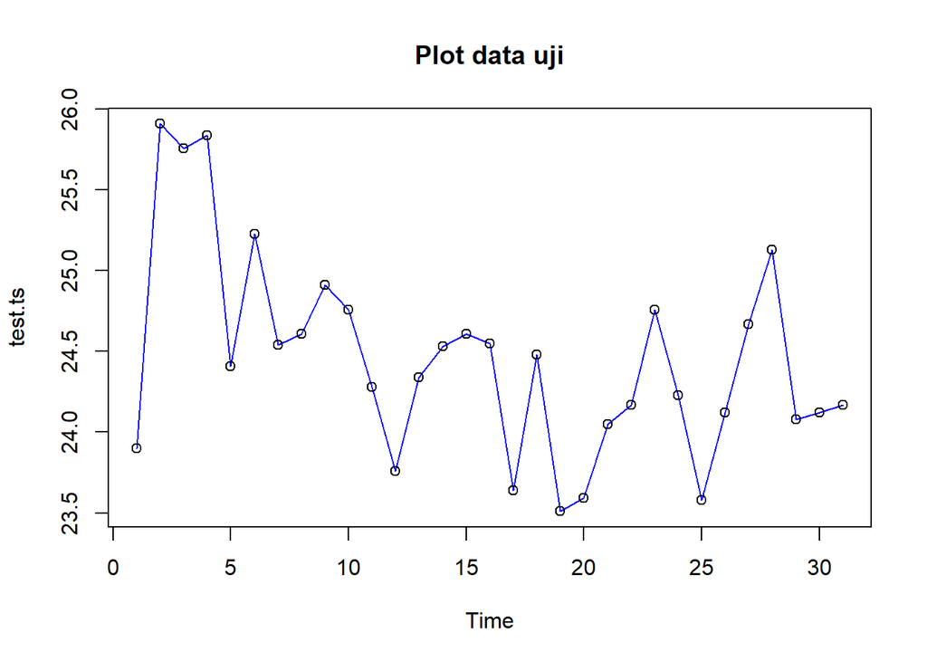

```r
plot(test.ts, col="blue",main="Plot data uji")
points(test.ts)
```

Eksplorasi data juga dapat dilakukan menggunakan package `ggplot2` .

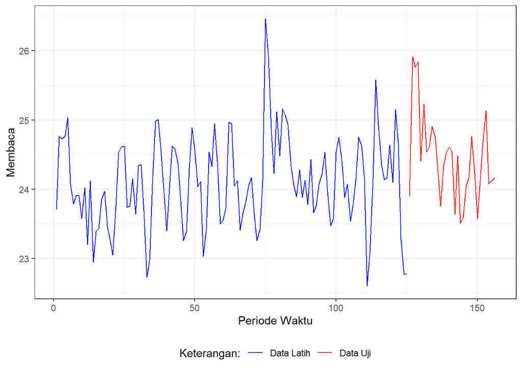

```r
#Eksplorasi dengan GGPLOT
library(ggplot2)
ggplot() +
  geom_line(data = training, aes(x = Periode, y = Suhu, col = "Data Latih")) +
  geom_line(data = testing, aes(x = Periode, y = Suhu, col = "Data Uji")) +
  labs(x = "Periode Waktu", y = "Membaca", color = "Legend") +
  scale_colour_manual(name="Keterangan:", breaks = c("Data Latih", "Data Uji"),
                      values = c("blue", "red")) +
  theme_bw() + theme(legend.position = "bottom",
                     plot.caption = element_text(hjust=0.5, size=12))
```

Single Exponential Smoothing merupakan metode pemulusan yang tepat digunakan untuk data dengan pola stasioner atau konstan.

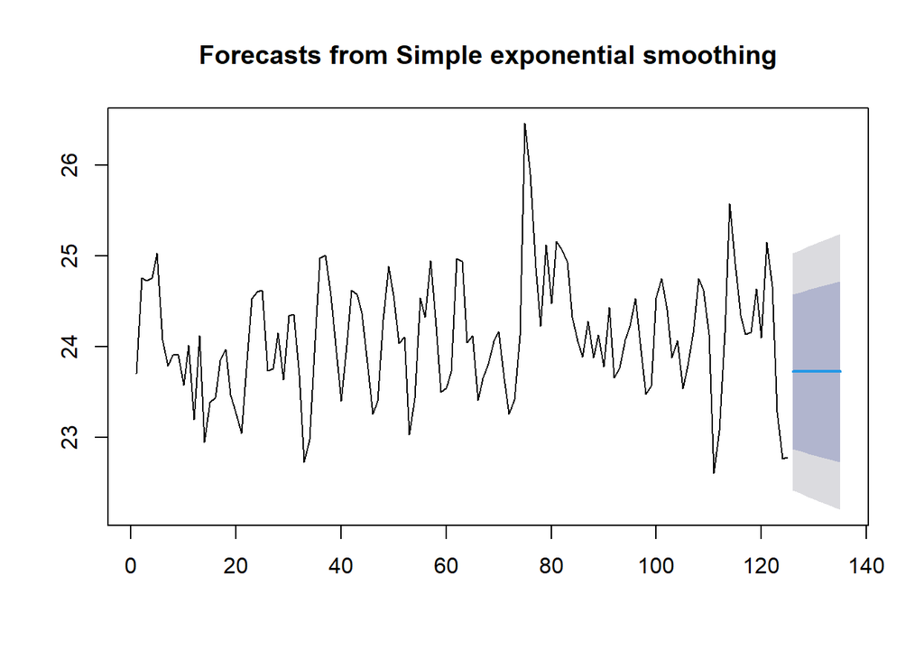

```r
#Cara 1 (fungsi ses)
ses.1 <- ses(train.ts, h = 10, alpha = 0.2)
plot(ses.1)
```

```r
ses.1
```

```
##     Point Forecast    Lo 80    Hi 80    Lo 95    Hi 95
## 126       23.72542 22.87305 24.57778 22.42183 25.02900
## 127       23.72542 22.85617 24.59466 22.39602 25.05481
## 128       23.72542 22.83961 24.61122 22.37069 25.08014
## 129       23.72542 22.82336 24.62747 22.34583 25.10500
## 130       23.72542 22.80739 24.64344 22.32141 25.12942
## 131       23.72542 22.79169 24.65914 22.29741 25.15342
## 132       23.72542 22.77626 24.67457 22.27381 25.17702
## 133       23.72542 22.76107 24.68976 22.25058 25.20025
## 134       23.72542 22.74612 24.70471 22.22771 25.22312
## 135       23.72542 22.73139 24.71944 22.20519 25.24564
```

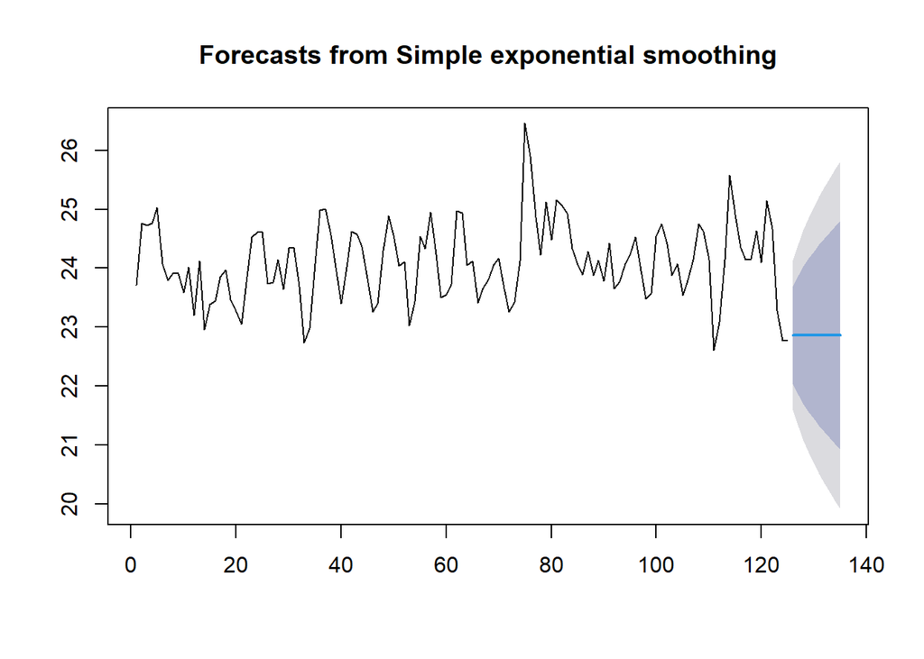

```r
ses.2<- ses(train.ts, h = 10, alpha = 0.7)
plot(ses.2)
```

```r
ses.2
```

```
##     Point Forecast    Lo 80    Hi 80    Lo 95    Hi 95
## 126       22.86206 22.03234 23.69178 21.59312 24.13100
## 127       22.86206 21.84926 23.87486 21.31312 24.41100
## 128       22.86206 21.69455 24.02958 21.07650 24.64762
## 129       22.86206 21.55806 24.16606 20.86776 24.85636
## 130       22.86206 21.43456 24.28956 20.67889 25.04523
## 131       22.86206 21.32093 24.40319 20.50511 25.21902
## 132       22.86206 21.21512 24.50900 20.34328 25.38084
## 133       22.86206 21.11571 24.60841 20.19125 25.53288
## 134       22.86206 21.02166 24.70246 20.04741 25.67671
## 135       22.86206 20.93219 24.79193 19.91058 25.81355
```

Untuk mendapatkan gambar hasil pemulusan pada data latih dengan fungsi `ses()` , perlu digunakan fungsi `autoplot()` dan `autolayer()` dari *library packages* `ggplot2` .

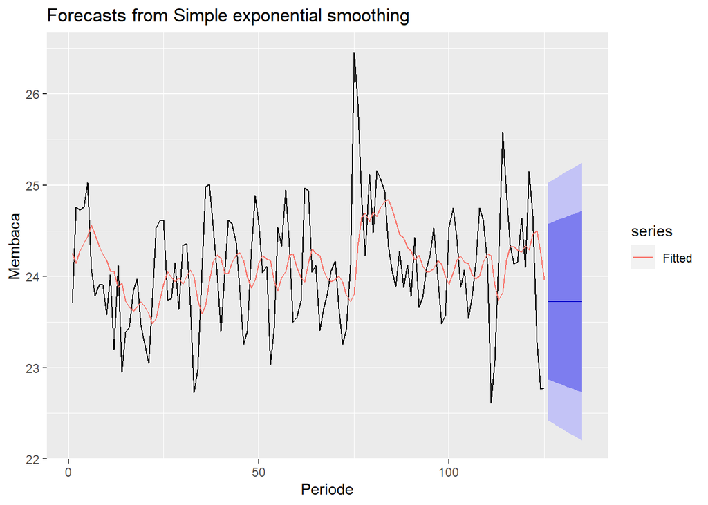

```r
autoplot(ses.1) +
  autolayer(fitted(ses.1), series="Fitted") +
  ylab("Membaca") + xlab("Periode")
```

Pada fungsi `ses()` , terdapat beberapa argumen yang umum digunakan, yaitu nilia `y` , `gamma` , `beta` , `alpha` , dan `h` .

Nilai `y` adalah nilai data deret waktu, `gamma` adalah parameter pemulusan untuk komponen musiman, `beta` adalah parameter pemulusan untuk tren, dan `alpha` adalah parameter pemulusan untuk stasioner, serta `h` adalah banyaknya periode yang akan diramalkan.

Kasus di atas merupakan contoh inisialisasi nilai parameter $\lambda$ dengan nilai `alpha` 0,2 dan 0,7 dan banyak periode data yang akan diramalkan adalah sebanyak 10 periode. Selanjutnya akan digunakan fungsi `HoltWinters()` dengan nilai inisialisasi parameter dan panjang periode peramalan yang sama dengan fungsi `ses()` .

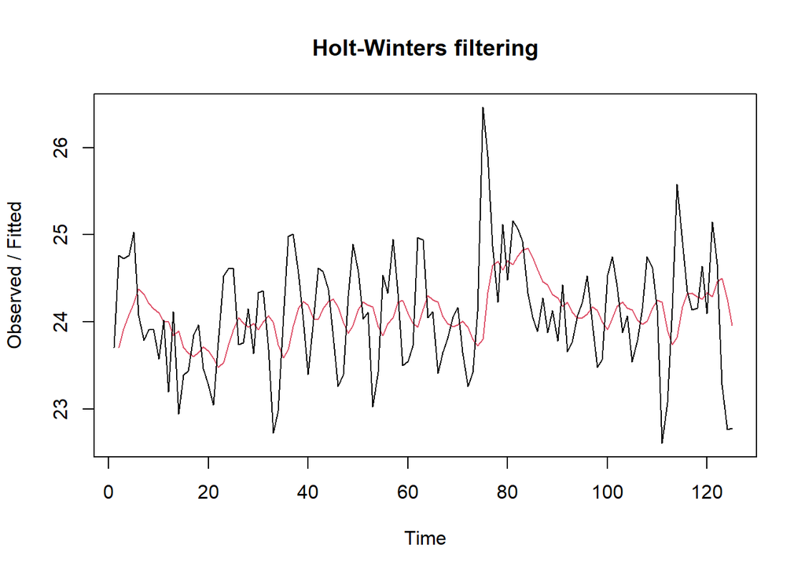

```r
#Cara 2 (fungsi Holtwinter)
ses1<- HoltWinters(train.ts, gamma = FALSE, beta = FALSE, alpha = 0.2)
plot(ses1)
```

```r
#ramalan
ramalan1<- forecast(ses1, h=10)
ramalan1
```

```
##     Point Forecast    Lo 80    Hi 80    Lo 95    Hi 95
## 126       23.72542 22.86657 24.58426 22.41192 25.03891
## 127       23.72542 22.84956 24.60127 22.38591 25.06492
## 128       23.72542 22.83287 24.61796 22.36039 25.09044
## 129       23.72542 22.81649 24.63434 22.33534 25.11549
## 130       23.72542 22.80041 24.65042 22.31074 25.14010
## 131       23.72542 22.78459 24.66624 22.28655 25.16428
## 132       23.72542 22.76904 24.68179 22.26277 25.18806
## 133       23.72542 22.75374 24.69709 22.23936 25.21147
## 134       23.72542 22.73867 24.71216 22.21632 25.23451
## 135       23.72542 22.72383 24.72700 22.19363 25.25720
```

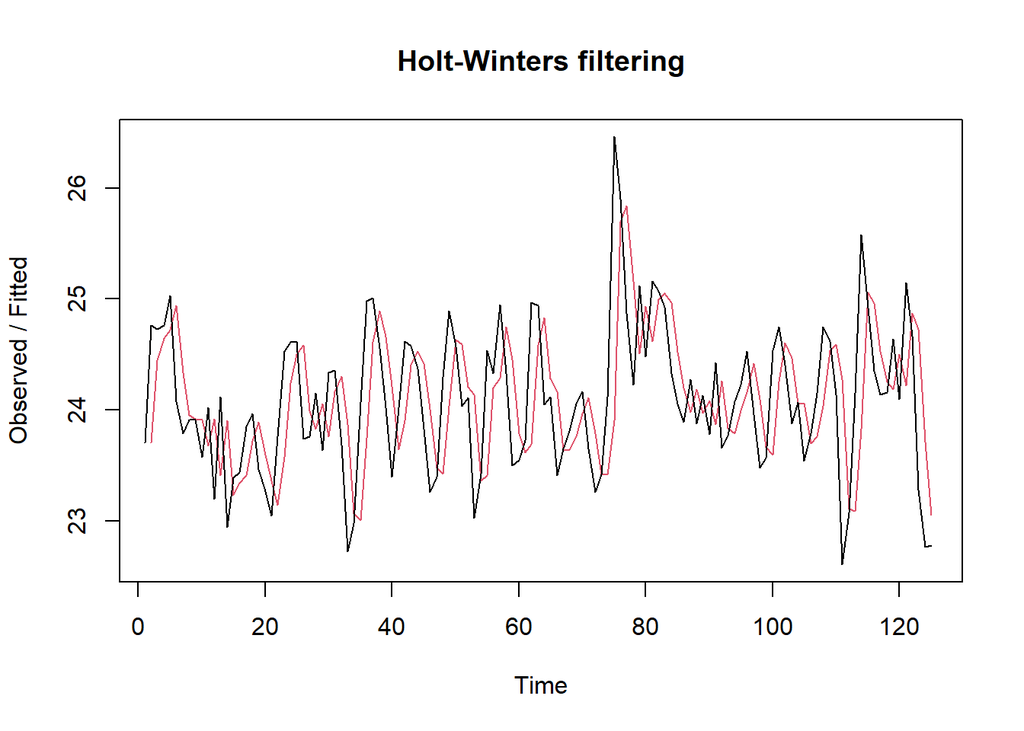

```r
ses2<- HoltWinters(train.ts, gamma = FALSE, beta = FALSE, alpha = 0.7)
plot(ses2)
```

```r
#ramalan
ramalan2<- forecast(ses2, h=10)
ramalan2
```

```
##     Point Forecast    Lo 80    Hi 80    Lo 95    Hi 95
## 126       22.86206 22.03158 23.69255 21.59194 24.13218
## 127       22.86206 21.84832 23.87580 21.31168 24.41244
## 128       22.86206 21.69346 24.03066 21.07485 24.64928
## 129       22.86206 21.55685 24.16727 20.86591 24.85821
## 130       22.86206 21.43324 24.29088 20.67687 25.04726
## 131       22.86206 21.31950 24.40462 20.50292 25.22120
## 132       22.86206 21.21359 24.51053 20.34095 25.38318
## 133       22.86206 21.11409 24.61003 20.18877 25.53535
## 134       22.86206 21.01995 24.70417 20.04480 25.67932
## 135       22.86206 20.93040 24.79372 19.90784 25.81628
```

Fungsi `HoltWinters` memiliki argumen yang sama dengan fungsi `ses()` . Argumen-argumen kedua fungsi dapat dilihat lebih lanjut dengan `?ses()` atau `?HoltWinters` .

Nilai parameter $\alpha$ dari kedua fungsi dapat dioptimalkan menyesuaikan dari *error*-nya paling minimumnya. Caranya adalah dengan membuat parameter $\alpha =$ `NULL` .

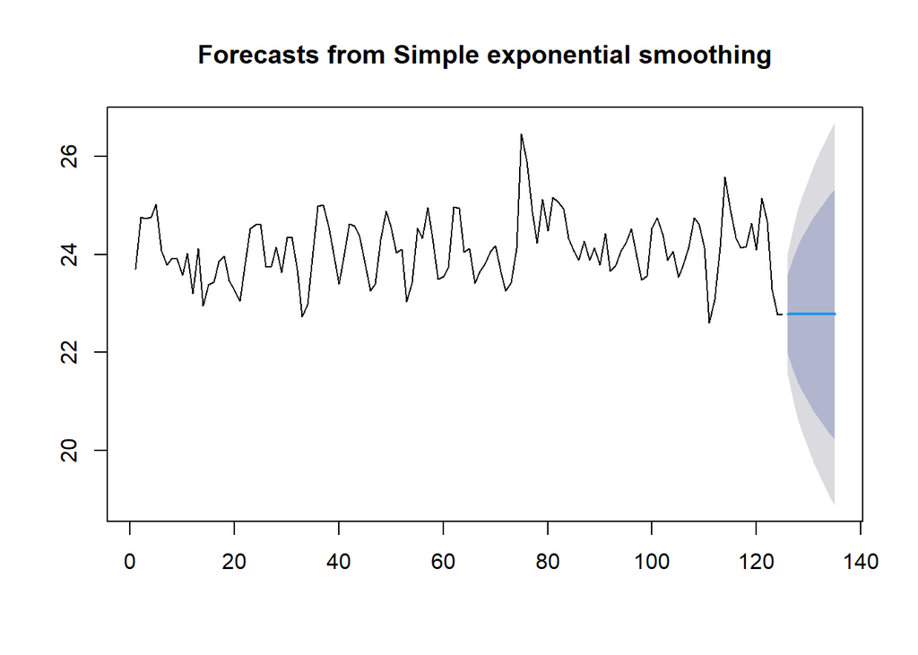

```r
#SES
ses.opt <- ses(train.ts, h = 10, alpha = NULL)
plot(ses.opt)
```

```r
ses.opt
```

```
##     Point Forecast    Lo 80    Hi 80    Lo 95    Hi 95
## 126          22.78 21.97104 23.58896 21.54280 24.01719
## 127          22.78 21.63602 23.92398 21.03043 24.52957
## 128          22.78 21.37894 24.18106 20.63726 24.92274
## 129          22.78 21.16221 24.39779 20.30580 25.25420
## 130          22.78 20.97126 24.58874 20.01377 25.54623
## 131          22.78 20.79863 24.76137 19.74976 25.81024
## 132          22.78 20.63988 24.92012 19.50697 26.05303
## 133          22.78 20.49212 25.06788 19.28099 26.27900
## 134          22.78 20.35334 25.20666 19.06875 26.49125
## 135          22.78 20.22208 25.33792 18.86800 26.69200
```

```r
#Lamda Optimum Holt Winter
sesopt<- HoltWinters(train.ts, gamma = FALSE, beta = FALSE,alpha = NULL)
sesopt
```

```
## Holt-Winters exponential smoothing without trend and without seasonal component.
##
## Call:
## HoltWinters(x = train.ts, alpha = NULL, beta = FALSE, gamma = FALSE)
##
## Smoothing parameters:
##  alpha: 0.9999339
##  beta : FALSE
##  gamma: FALSE
##
## Coefficients:
##    [,1]
## a 22.78
```

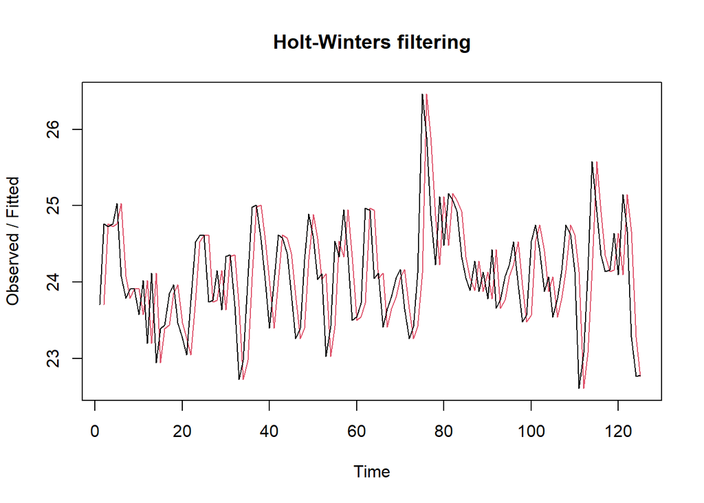

```r
plot(sesopt)
```

```r
#ramalan
ramalanopt<- forecast(sesopt, h=10)
ramalanopt
```

```
##     Point Forecast    Lo 80    Hi 80    Lo 95    Hi 95
## 126          22.78 21.97110 23.58890 21.54289 24.01710
## 127          22.78 21.63608 23.92392 21.03053 24.52947
## 128          22.78 21.37901 24.18099 20.63737 24.92263
## 129          22.78 21.16228 24.39772 20.30591 25.25409
## 130          22.78 20.97134 24.58866 20.01390 25.54610
## 131          22.78 20.79872 24.76128 19.74989 25.81011
## 132          22.78 20.63997 24.92002 19.50711 26.05289
## 133          22.78 20.49222 25.06778 19.28114 26.27886
## 134          22.78 20.35344 25.20655 19.06890 26.49110
## 135          22.78 20.22219 25.33781 18.86816 26.69184
```

Setelah dilakukan peramalan, akan dilakukan perhitungan keakuratan hasil peramalan. Perhitungan akurasi ini dilakukan baik pada data latih dan data uji.

#### Akurasi Data Latih

Perhitungan akurasi data dapat dilakukan dengan cara langsung maupun manual. Secara langsung, nilai akurasi dapat diambil dari objek yang tersimpan pada hasil SES, yaitu *sum of squared errors* (SSE). Nilai akurasi lain dapat dihitung pula dari nilai SSE tersebut.

```r
#Keakuratan Metode
#Pada data training
SSE1<-ses1$SSE
MSE1<-ses1$SSE/length(train.ts)
RMSE1<-sqrt(MSE1)

akurasi1 <- matrix(c(SSE1,MSE1,RMSE1))
row.names(akurasi1)<- c("SSE", "MSE", "RMSE")
colnames(akurasi1) <- c("Akurasi lamda=0.2")
akurasi1
```

```
##      Akurasi lamda=0.2
## SSE         55.2417885
## MSE          0.4419343
## RMSE         0.6647814
```

```r
SSE2<-ses2$SSE
MSE2<-ses2$SSE/length(train.ts)
RMSE2<-sqrt(MSE2)

akurasi2 <- matrix(c(SSE2,MSE2,RMSE2))
row.names(akurasi2)<- c("SSE", "MSE", "RMSE")
colnames(akurasi2) <- c("Akurasi lamda=0.7")
akurasi2
```

```
##      Akurasi lamda=0.7
## SSE         51.6651322
## MSE          0.4133211
## RMSE         0.6429005
```

```r
#Cara Manual
fitted1<-ramalan1$fitted
sisaan1<-ramalan1$residuals
head(sisaan1)
```

```
## Time Series:
## Start = 1
## End = 6
## Frequency = 1
## [1]       NA  1.05000  0.81000  0.67800  0.81240 -0.30008
```

```r
resid1<-training$Suhu-ramalan1$fitted
head(resid1)
```

```
## Time Series:
## Start = 1
## End = 6
## Frequency = 1
## [1]       NA  1.05000  0.81000  0.67800  0.81240 -0.30008
```